# Visualizing Distributions

### A basic histogram

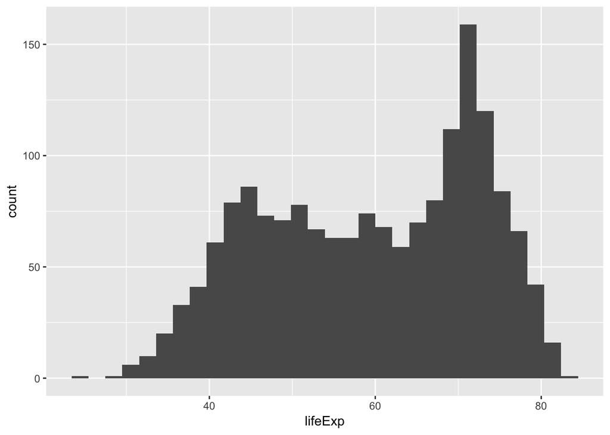

```r
ggplot(gapminder, aes(lifeExp)) +
  geom_histogram()
```

### Adjusting the bin width

Adjusting the binwdith of your data can change the interpretation.

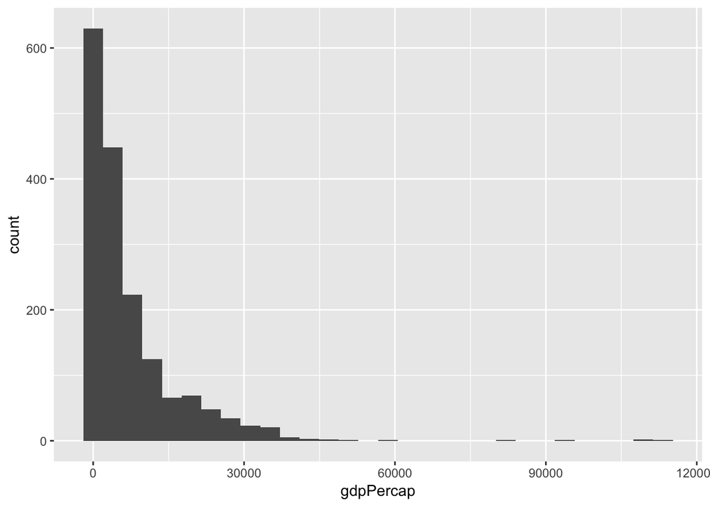

```r
ggplot(gapminder, aes(gdpPercap)) +
  geom_histogram(bins = 30)
```

### Changing the colors of your histogram

```r
#store continents in a list
continents <- c("Africa", "Americas", "Asia", "Europe", "Oceania")

#create a function that will assign the continent names to a color. The function takes three inputs: the list of variables to be colored (e.g. continent names), the type of laCroix palette, and the start of the index. change the index_start to 0 or 1 to get variations of laCroix palette.
set_continent_color <- function(continent_names, lacroix_color, index_start) {

  #create empty vector to store values
  output <- vector("character", length(continent_names))

  #loop over the length of the list of continent names, and assign a color to each continent
  for (i in seq_along(continent_names)) {
    output[[i]] <- lacroix_color[[index_start + i]]
  }
  output

}
```

#### Plot the histogram.

Set custom colors using the `set_continent_color` function in the `scale_fill_manual` function.

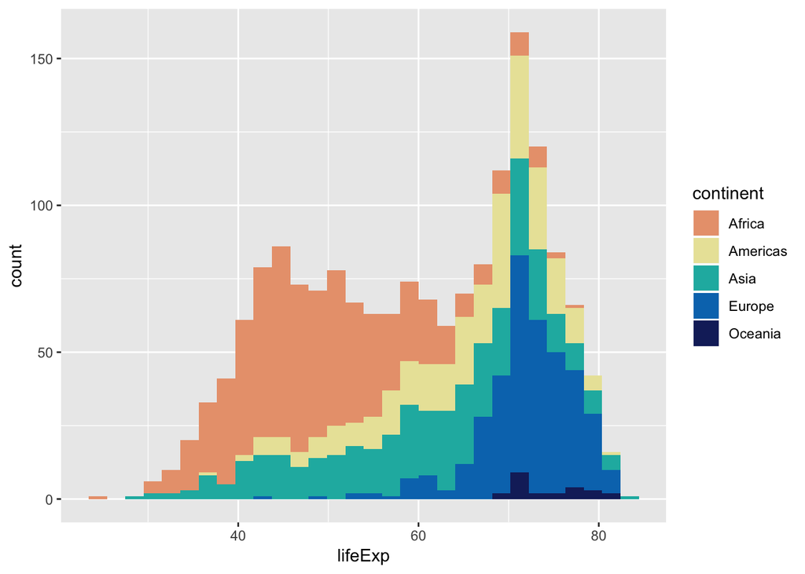

```r
ggplot(gapminder, aes(lifeExp, fill = continent)) +
  geom_histogram() +
  scale_fill_manual(values = set_continent_color(continents, PeachPear, 1))
```

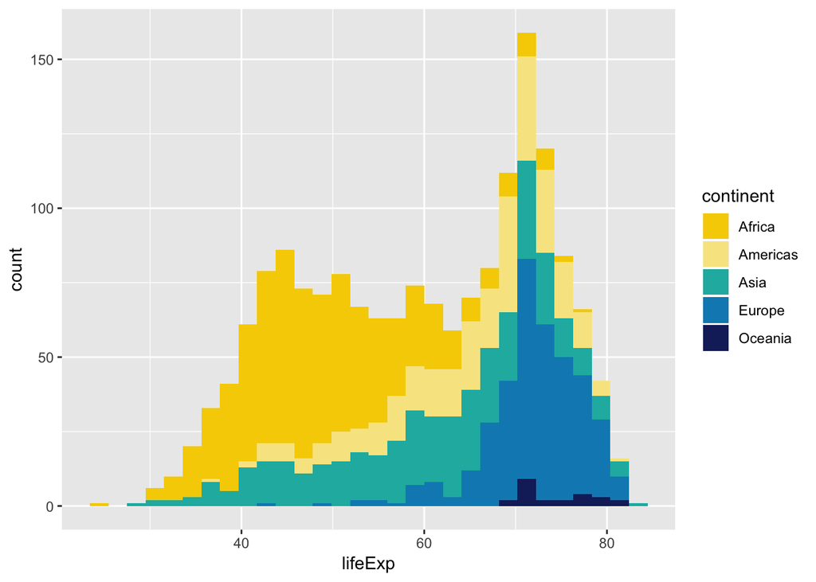

```r
ggplot(gapminder, aes(lifeExp, fill = continent)) +
  geom_histogram() +
  scale_fill_manual(values = set_continent_color(continents, Lemon, 1))
```

## Density Plots

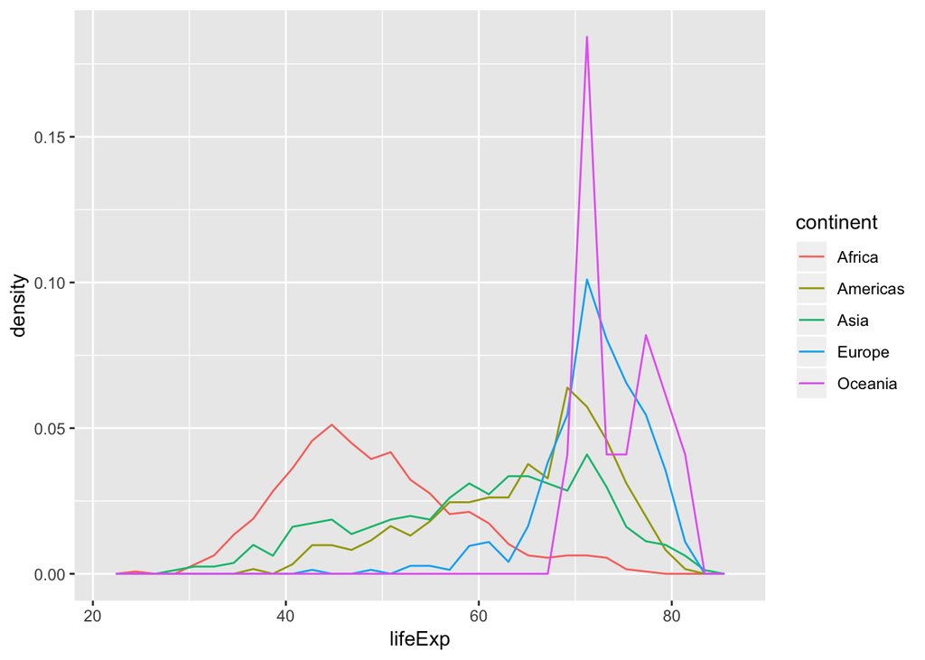

```r
ggplot(gapminder, aes(lifeExp, stat(density), colour = continent)) +
  geom_freqpoly()
```

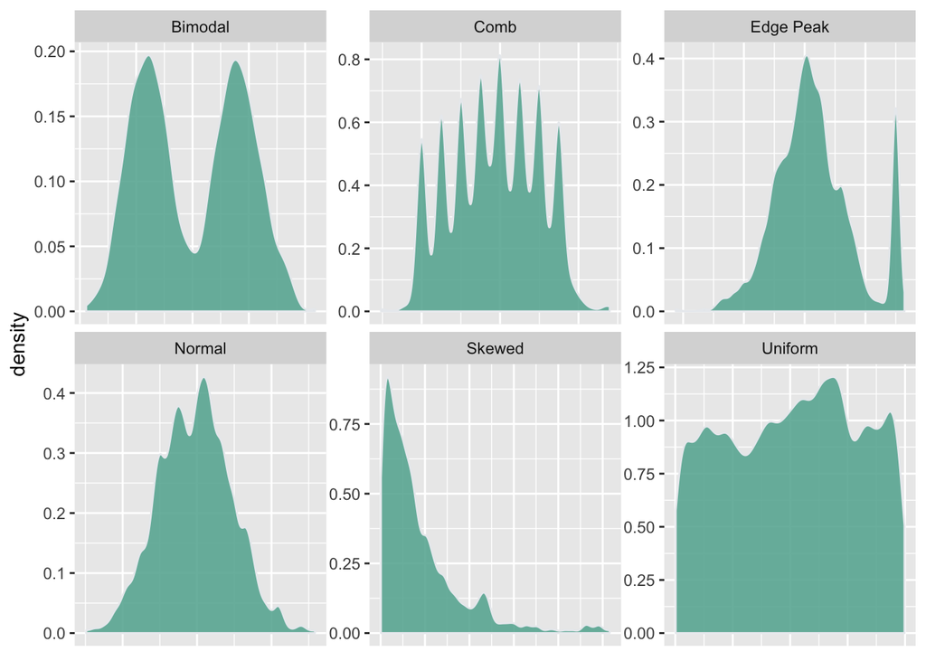

```r
# Build dataset with different distributions
data <- data.frame(
  type = c( rep("Edge Peak", 1000),
            rep("Comb", 1000),
            rep("Normal", 1000),
            rep("Uniform", 1000),
            rep("Bimodal", 1000),
            rep("Skewed", 1000) ),
  value = c( rnorm(900), rep(3, 100),
             rnorm(360, sd=0.5), rep(c(-1,-0.75,-0.5,-0.25,0,0.25,0.5,0.75), 80),
             rnorm(1000), runif(1000),
             rnorm(500, mean=-2),
             rnorm(500, mean=2), abs(log(rnorm(1000))) )
)

# Represent it
data %>%
  ggplot( aes(x=value)) +
    geom_density(fill="#69b3a2", color="#e9ecef", alpha=0.9, adjust = 0.5) +
    facet_wrap(~type, scale="free") +
    theme(
      panel.spacing = unit(0.1, "lines"),
      axis.title.x=element_blank(),
      axis.text.x=element_blank(),
      axis.ticks.x=element_blank()
    )
```

## Resources

Read more about different visualization types and how to build them from the following resources:

- [Data to Viz](https://www.data-to-viz.com/)  
  *From Data to Viz leads you to the most appropriate graph for your data. It links to the code to build it and lists common caveats you should avoid.*